# Problema 3 Checkpoint 1

```r
library(dplyr)
library(corrplot)
library(ggplot2)
library(reshape2)
library(ggfortify)
library(cluster)
library(ggdendro)
theme_set(theme_bw())
```

```r
emendas.areas.parlamentar <- read.csv("emendas_area_parlamentar.csv")
```

Vamos inicialmente ver a estrutura dos dados que iremos trabalhar:

```r
emendas.areas.parlamentar %>% head()
```

```
##                NOME_PARLAMENTAR Agricultura Assistência.Social
## 1 ABEL SALVADOR MESQUITA JUNIOR           0               0.00
## 2            ABELARDO CAMARINHA           0           11665.61
## 3               ABELARDO LUPION           0          206073.89
## 4            ABERLADO CAMARINHA           0               0.00
## 5                  ACELINO POPO           0          925698.77
## 6                  ACIR GURGACZ           0           88947.00
##   Ciência.e.Tecnologia Comércio.e.Serviços  Cultura Defesa.Nacional
## 1                  0.0                0.00     0.00          3000.0
## 2             234296.3                0.00     0.00             0.0
## 3                  0.0            12500.00 12500.00             0.0
## 4                  0.0                0.00     0.00             0.0
## 5                  0.0            44556.25 44556.25             0.0
## 6                  0.0                0.00     0.00        920420.5
##   Desporto.e.Lazer Direitos.da.Cidadania Gestão.Ambiental Indústria
```

[output cut: 20 more lines]

Vemos que cada observação é um parlamentar, onde a primeira coluna é o nome do mesmo, e as demais representam o investimento total que ele fez na área especificada.

Vamos ver como se comportam os dados das áreas:

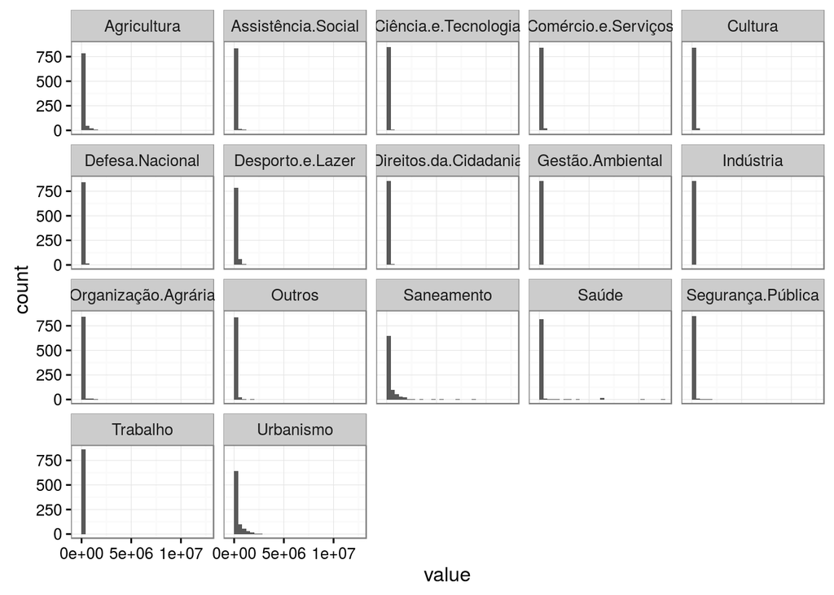

```r
melted.emendas.areas.parlamentar <- melt(emendas.areas.parlamentar, id=c("NOME_PARLAMENTAR"))

ggplot(melted.emendas.areas.parlamentar, aes(value)) +
  geom_histogram() +
  facet_wrap(~variable)
```

Como vemos, os dados são bastante enviesados, logo iremos utilizar a função log em cima dos mesmos:

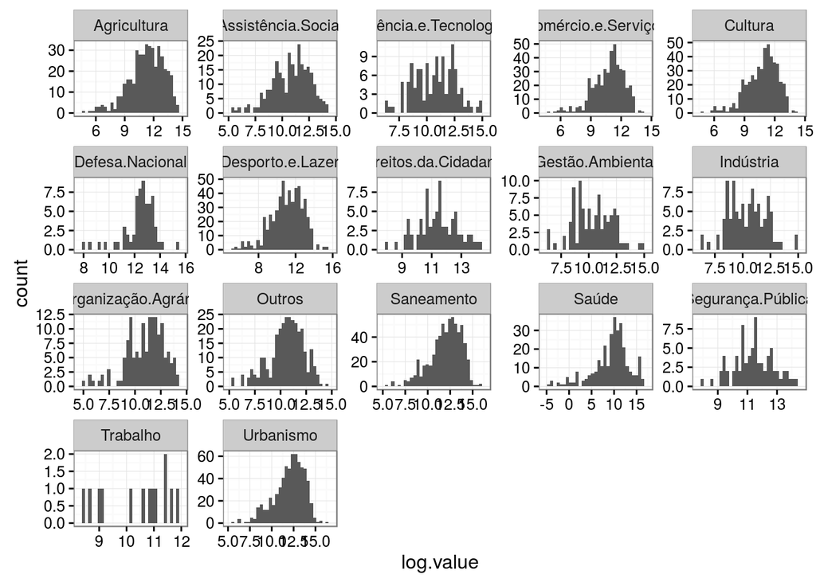

```r
melted.emendas.areas.parlamentar <- melted.emendas.areas.parlamentar %>%
  mutate(
    log.value = log(value)
  )

ggplot(melted.emendas.areas.parlamentar, aes(log.value)) +
  geom_histogram() +
  facet_wrap(~variable, scales = "free")
```

Grande parte dos dados parecem seguir uma distribuição normal, ou pelo menos próximo de uma normal.

Agora, vamos ver se existe correlação entre as áreas especificadas:

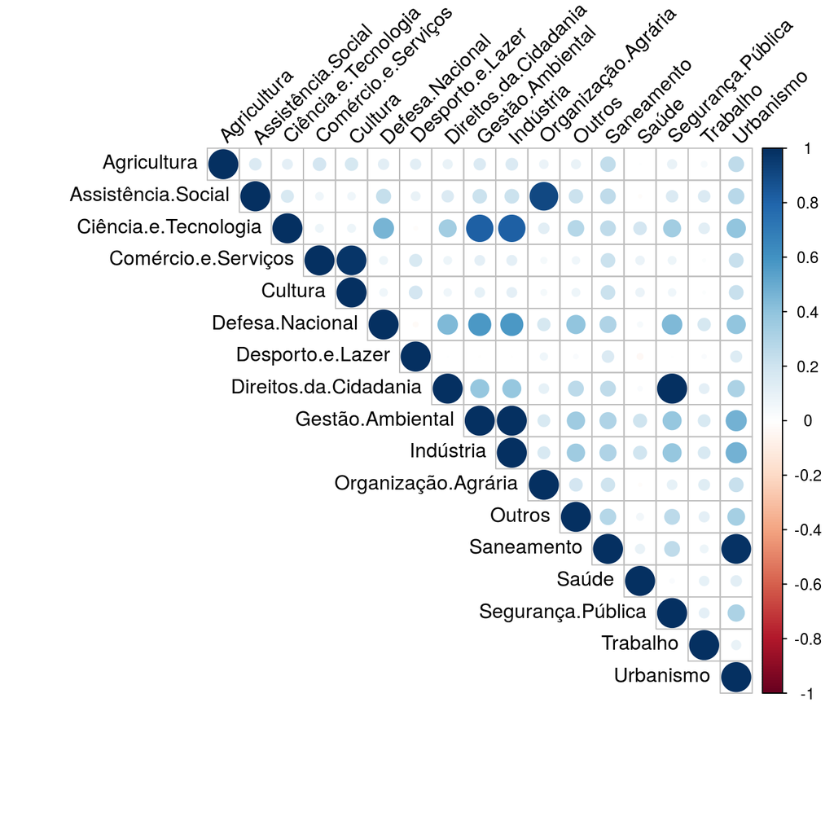

```r
corr.emendas.areas.parlamentar <- cor(emendas.areas.parlamentar %>% select(-NOME_PARLAMENTAR))
corrplot(corr.emendas.areas.parlamentar, type="upper", tl.col="black", tl.srt=45)
```

Vemos que as áreas com maior correlação são:

- Comércio e Serviços com Cultura
- Direito da cidadania com Segurança Pública
- Gestão Ambiental com Indústria
- Saneamento com Urbanismo
- Assistência Social com Organização Agrária
- Ciencia e Tecnologia com Gestão Ambiental
- Ciencia e Tecnologia com Indústria

Os demais tem correlação não muito alta, ou próximo de zero.

O mesmo pode ser verificado ao aplicar a função logarítmica logs:

```r
melted.emendas.areas.parlamentar <- melted.emendas.areas.parlamentar %>%
  mutate(
    log.value = ifelse(is.infinite(log.value), 0, log(value))
  )

log.emendas.areas.parlamentar <- dcast((melted.emendas.areas.parlamentar %>% select(-value)), NOME_PARLAMENTAR  ~ variable)
```

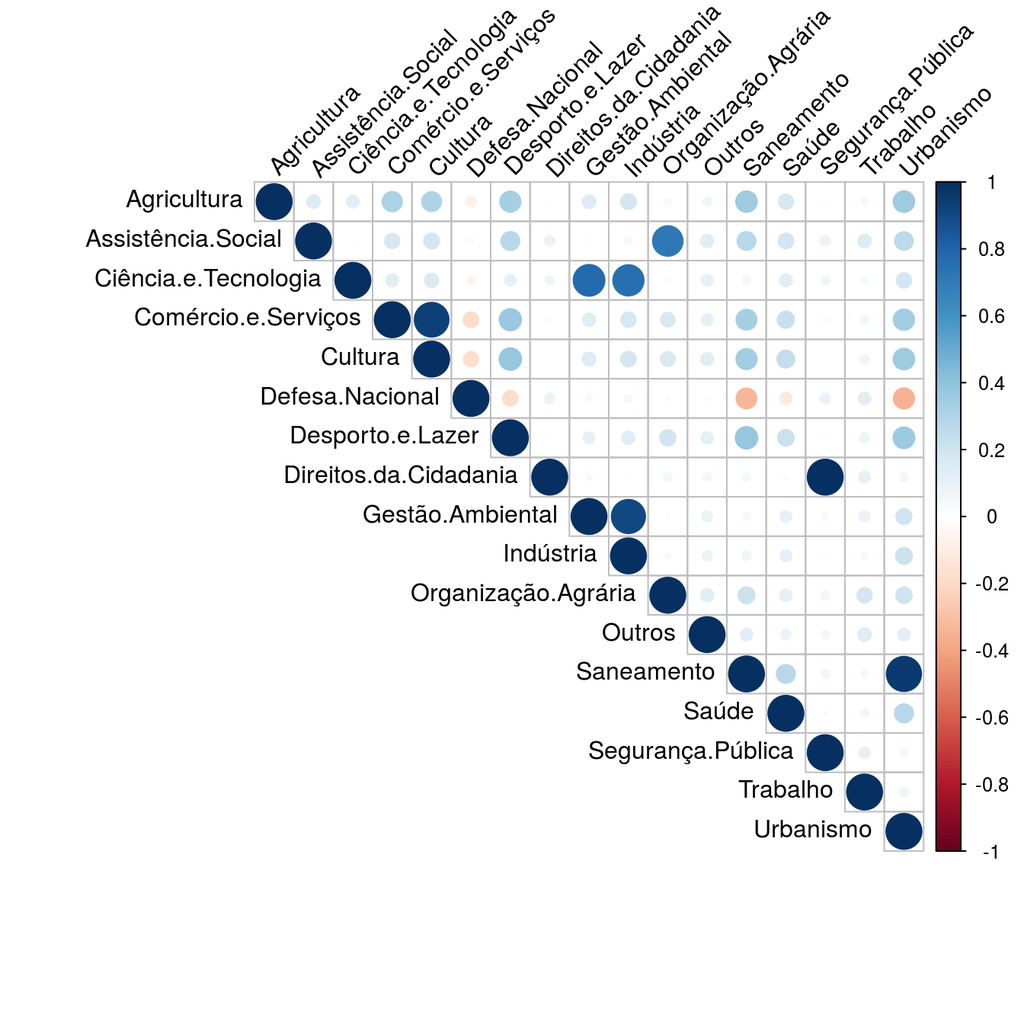

```r
corr.log.emendas.areas.parlamentar <- cor(log.emendas.areas.parlamentar %>% select(-NOME_PARLAMENTAR))
corrplot(corr.log.emendas.areas.parlamentar, type="upper", tl.col="black", tl.srt=45)
```

##### (i) que método escolheu usar e por que?

- Como pudemos ver acima, a maioria das variáveis parecem seguir uma distribuição normal, porém ao vermos o correlograma percebemos que poucas áreas têm alta correlação. Com isso podemos imaginar que não existe uma ordem hierarquia associada aos dados, visto a baixa correlação entre as áreas, logo iremos agrupar usando K-means.

Agora iremos agrupar os parlamentares de acordo com seus gastos em diferentes áreas:

##### (ii) que parâmetros usou no método e por que?

- Para escolher o número de clusters, iremos iniciar com 2 e analisar se a medida que aumentamos a quantidade, eles são mais representativos, ou não até encontrar um valor satisfatório. Para garantir que o K-means não deu azar de pegar um grupo pouco significativo, será repetido 10 vezes o algoritmo.

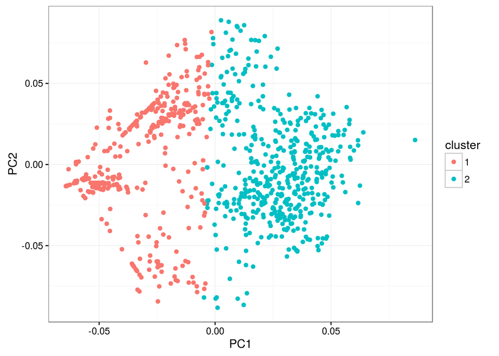

```r
log.emendas.areas.parlamentar <- log.emendas.areas.parlamentar %>%
  mutate(
      NOME_PARLAMENTAR = ifelse(is.na(NOME_PARLAMENTAR), "Outro", NOME_PARLAMENTAR)
    )

cluster.areas.emendas <- log.emendas.areas.parlamentar %>% select(-NOME_PARLAMENTAR)
row.names(cluster.areas.emendas) <- log.emendas.areas.parlamentar$NOME_PARLAMENTAR
distancias <- dist(cluster.areas.emendas)

km2 <- kmeans(cluster.areas.emendas, centers = 2, nstart = 10)

autoplot(km2, data = log.emendas.areas.parlamentar)
```

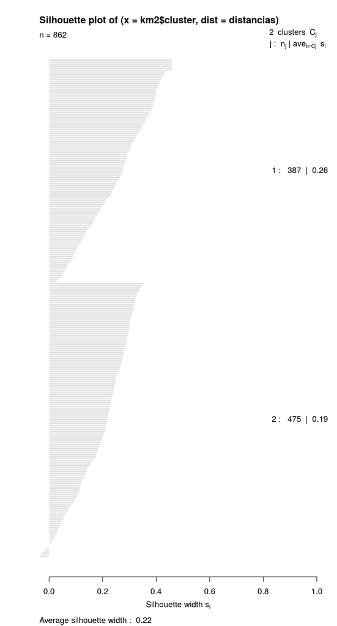

```r
plot(silhouette(km2$cluster, distancias), col = "black")
```

Como vemos, ao agrupar os pontos em 2 grupos, os mesmo ficam bem divididos. A largura média da silhueta é de 0.22, onde o ideal é que se aproximasse de 1 e tem poucas abaixo de zero.

Vamos aumentar para 3 grupos:

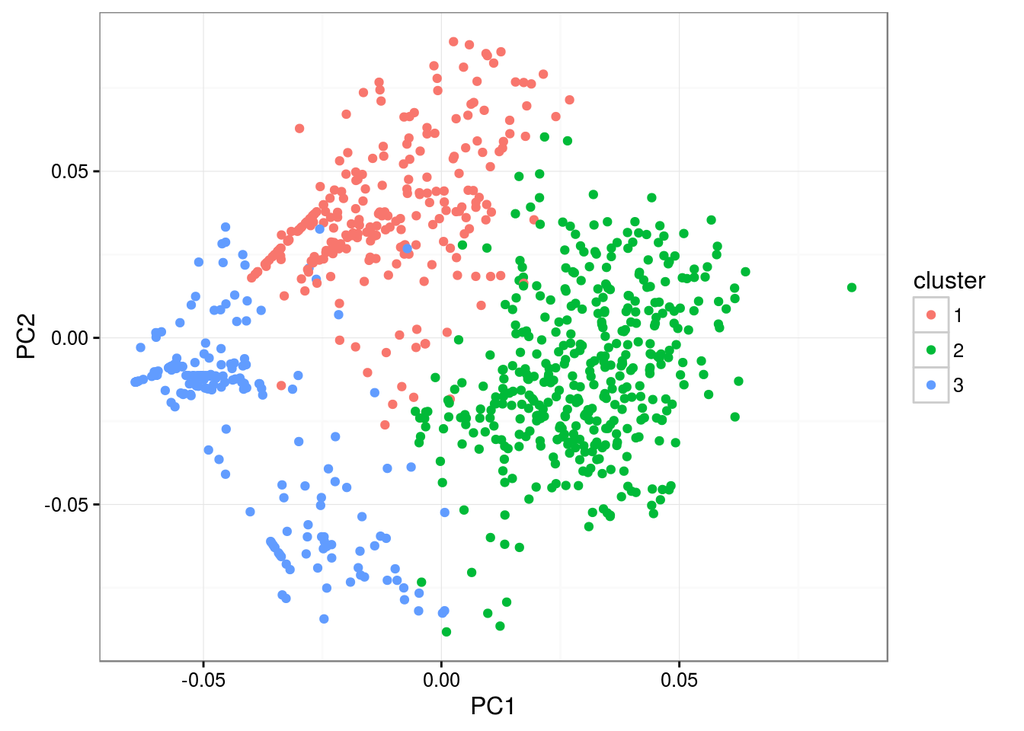

```r
km3 <- kmeans(cluster.areas.emendas, centers = 3, nstart = 10)

autoplot(km3, data = log.emendas.areas.parlamentar)
```

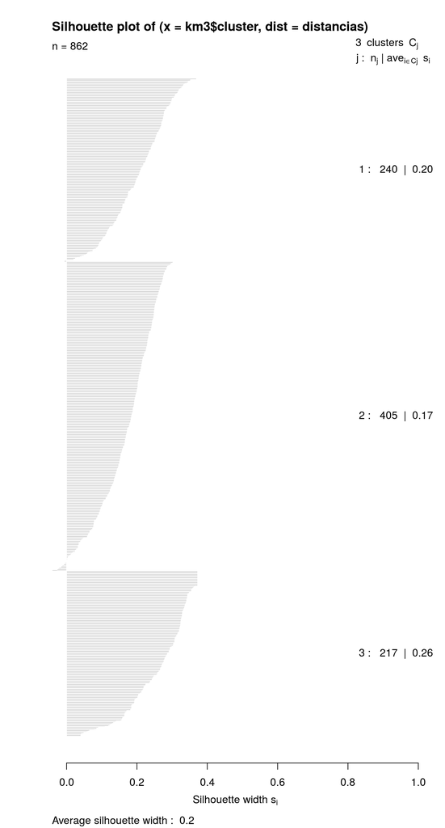

```r
plot(silhouette(km3$cluster, distancias), col = "black")
```

Como vemos, os grupos também ficam bem divididos, porém não tem mais uma “margem” que os separa. A largura média da silhueta é de 0.2 e tem poucas abaixo de zero.

Vamos aumentar para 4 grupos:

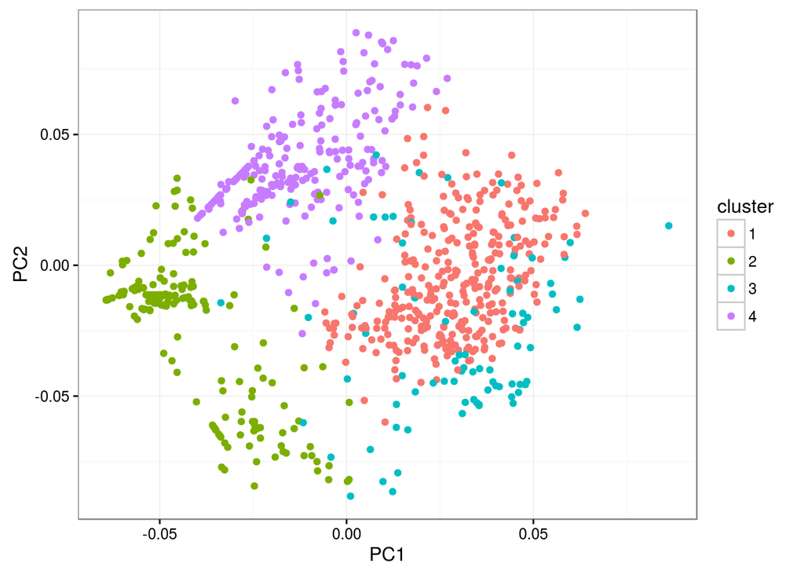

```r
km4 <- kmeans(cluster.areas.emendas, centers = 4, nstart = 10)

autoplot(km4, data = log.emendas.areas.parlamentar)
```

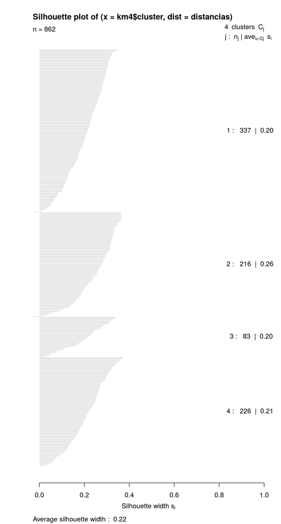

```r
plot(silhouette(km4$cluster, distancias), col = "black")
```

Como a tendência é os pontos cada vez ficarem mais difusos, vamos parar com 4 grupos.

##### (iii) qual a qualidade do agrupamento final encontrado

Utilizamos anteriormente a silhueta para medir a qualidade do agrupamento, onde a mesma varia entre -1 e 1. Quanto mais próximo de 1, mais representativos são os grupos. Com isso, a qualidade do agrupamento final encontrado é razoável, tendo em vista que uma largura média da silhueta é de 0.22.

##### (iv) que conclusões é possível tirar sobre os dados (no vocabulário do domínio do problema) através dos métodos.

Para responder esta pergunta veremos se os grupos tem relação com o maior tipo de gasto de cada parlamentar:

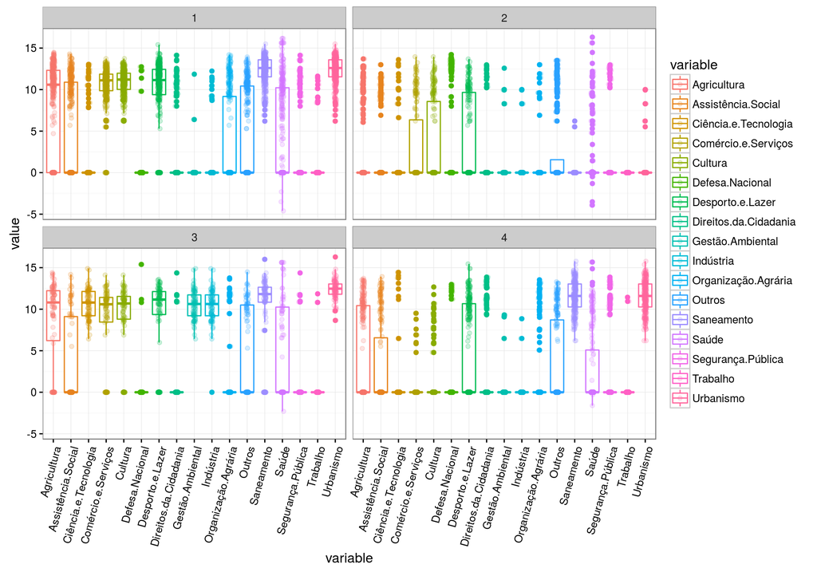

```r
log.emendas.areas.parlamentar$group <- km4$cluster
melted.log.emendas.areas.parlamentar <- melt(log.emendas.areas.parlamentar, id=c("NOME_PARLAMENTAR", "group"))

ggplot(melted.log.emendas.areas.parlamentar, aes(x = variable, y = value, colour = variable)) +
  geom_boxplot() +
  geom_point(alpha = 0.2, position = position_jitter(width = .2)) +
  theme(axis.text.x = element_text(angle = 75, hjust = 1)) +
  facet_wrap(~ group)
```